# Déterminants de la durée du trajet dans le système Ford GoBike

## Par Patrick Mballa

## Aperçu de l'enquête

> Ce travail propose d'étudier les déterminants de la durée de trajet afin de prédire les trajets les plus longs. Un accent particulier a été mis sur le jour de la semaine où le trajet est effectué, sur le type d'utilisateur et le genre.

## Aperçu de l'ensemble des données

> L'ensemble de données traité comprend 183412 trajets individuels avec 16 caractéristiques pour chacun de ces trajets. Tel que l'ensemble des données est transmis, 9 caractéristiques des trajets sont numériques et les autres caractéristiques sont des données qualitatives. Cependant, il nous avons quelque peu modifié cet ensemble de donné en supprimant les lignes avec des données manquantes, en remplaçant les années de naissance par les âges, en crééant de nouvelles colonnes (jour de la semaine par exemple) etc. A la fin de ce traitement, on a obtenu et utilisé un ensemble de données ayant 174952 lignes et 22 colonnes. Parmi ces colonnes, 6 sont de type numérique/quantitatif, 10 sont de type qualitatif nominal, 4 sont de type qualitatif ordinale (les mois et les jours de la semaine), le deux autres sont de type datetime.

## Distribution de la durée en secondes du trajet

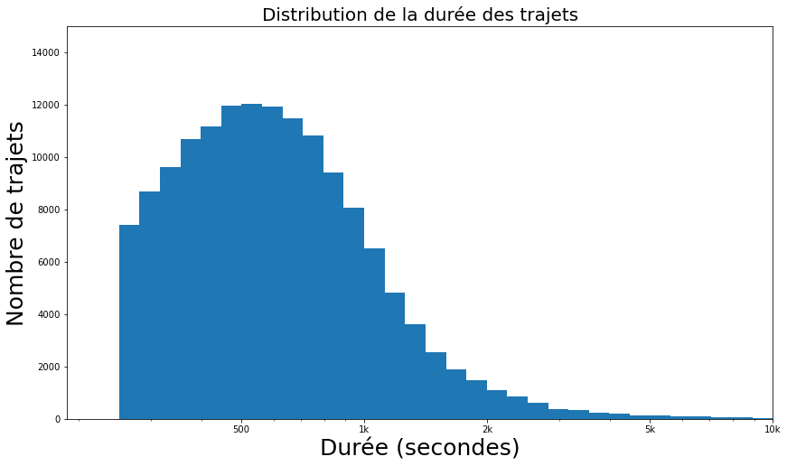

## Rapport entre durée du trajet et type d'utilisateur

> Le pourcentage de clients qui effectuent des trajets de plus longue durée est supérieure au pourcentage d'abonnés qui effectuent des trajets de plus longue durée.

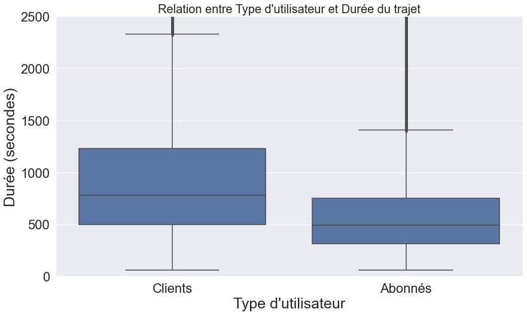

## Rapport entre durée du trajet, le jour de la semaine et le type d'utilisateur.

> Les clients font des trajets de plus longue durée que les abonnées, cela indépendament du jour de la semaine. Par ailleurs, Les clients du week-end font des trajets de plus longue durée que tous les autres utilisateurs.

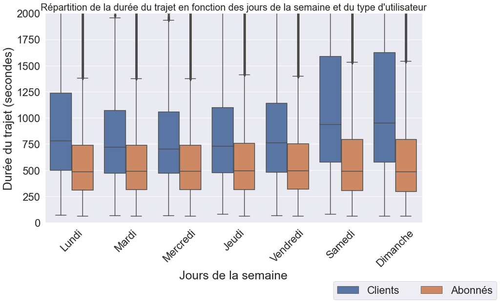

## Répartition de la durée moyenne en fonction du genre et du type d'utilsateur

> Le classement en ordre décroissant de la durée moyenne du trajet par genre et par type d'utilisateur est le suivant: les clients du genre autre (environ 1603 secondes); les clients femmes ( environ 1425 secondes); les clients hommes (environ 1254 secondes); les abonnés du genre autre (environ 913 secondes); les abonnés femmes (environ 697 secondes) et enfin les abonnés hommes (environ 617 secondes)

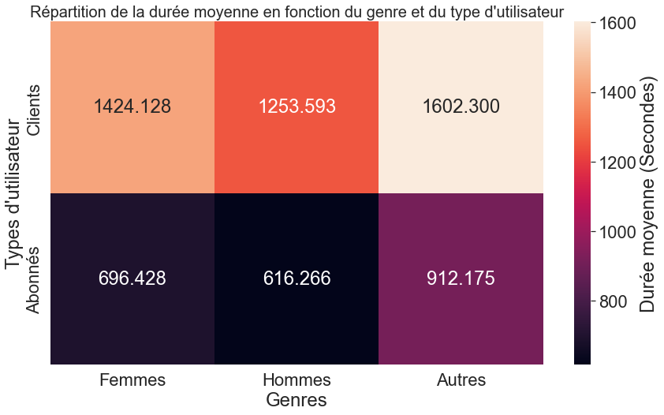